# Bella_Beat_Analysis

ThankGod Agada

2022-11-20

##### Setting up my enviroment

To load packages needed to manipulate, analyze and visualize the data

```r
library(tidyverse)
library(readr)
library(skimr)
library(dplyr)
library(tidyr)
library(lubridate)
```

```r
library(ggplot2)
library(scales)
library(ggpubr)
library(ggsci)
library(viridis)
library(RColorBrewer)
library(ggrepel)
```

#### To load and import the files needed

```r
Daily_Activity <- read.csv("/Users/DieuMerci/Downloads/Coursera_Capstone/Fitabase Data 4.12.16-5.12.16/dailyActivity_merged.csv")
Daily_Sleep <- read.csv("/Users/DieuMerci/Downloads/Coursera_Capstone/Fitabase Data 4.12.16-5.12.16/sleepDay_merged.csv")
Minute_Sleep <- read.csv("/Users/DieuMerci/Downloads/Coursera_Capstone/Fitabase Data 4.12.16-5.12.16/minuteSleep_merged.csv")
Hourly_Steps <- read.csv("/Users/DieuMerci/Downloads/Coursera_Capstone/Fitabase Data 4.12.16-5.12.16/hourlySteps_merged.csv")
```

#### To check for distinct users/participant using n_distinct() functions.

```r
n_distinct(Daily_Activity$Id)
```

```
## [1] 33
```

```r
n_distinct(Daily_Sleep$Id)
```

```
## [1] 24
```

```r
n_distinct(Minute_Sleep$Id)
```

```
## [1] 24
```

```r
n_distinct(Hourly_Steps$Id)
```

```
## [1] 33
```

#### To check for numbers of duplicated rows in each datasets using sum() and duplicated() functions

```r
sum(duplicated(Daily_Activity))
```

```
## [1] 0
```

```r
sum(duplicated(Daily_Sleep))
```

```
## [1] 3
```

```r
sum(duplicated(Minute_Sleep))
```

```
## [1] 543
```

```r
sum(duplicated(Hourly_Steps))
```

```
## [1] 0
```

#### To remove the duplicates from Daily_Sleep and Minute_Sleep dataframe using distinct() and drop_na() function

```r
Daily_Sleep <- Daily_Sleep %>%
  distinct() %>%
  drop_na()

Minute_Sleep <- Minute_Sleep %>%
  distinct() %>%
  drop_na()
```

#### To check for NA’s using colSums() and is.na() functions

```r
colSums(is.na(Daily_Activity))
```

```
##                       Id             ActivityDate               TotalSteps
##                        0                        0                        0
##            TotalDistance          TrackerDistance LoggedActivitiesDistance
##                        0                        0                        0
##       VeryActiveDistance ModeratelyActiveDistance      LightActiveDistance
##                        0                        0                        0
##  SedentaryActiveDistance        VeryActiveMinutes      FairlyActiveMinutes
##                        0                        0                        0
##     LightlyActiveMinutes         SedentaryMinutes                 Calories
##                        0                        0                        0
```

```r
colSums(is.na(Daily_Sleep))
```

```
##                 Id           SleepDay  TotalSleepRecords TotalMinutesAsleep
##                  0                  0                  0                  0
##     TotalTimeInBed
##                  0
```

```r
colSums(is.na(Minute_Sleep))
```

```
##    Id  date value logId
##     0     0     0     0
```

```r
colSums(is.na(Hourly_Steps))
```

```
##           Id ActivityHour    StepTotal
##            0            0            0
```

#### To check for NULLs using is.null() function

```r
is.null(Daily_Activity)
```

```
## [1] FALSE
```

```r
is.null(Daily_Sleep)
```

```
## [1] FALSE
```

```r
is.null(Minute_Sleep)
```

```
## [1] FALSE
```

```r
is.null(Hourly_Steps)
```

```
## [1] FALSE
```

#### To understand the structure and shape of the data frames

```r
skim_without_charts(Daily_Activity)
```

Data summary

| Name | Daily_Activity |
| --- | --- |
| Number of rows | 940 |
| Number of columns | 15 |
| _______________________ |  |
| Column type frequency: |  |
| character | 1 |
| numeric | 14 |
| ________________________ |  |
| Group variables | None |

**Variable type: character**

| skim_variable | n_missing | complete_rate | min | max | empty | n_unique | whitespace |
| --- | --- | --- | --- | --- | --- | --- | --- |
| ActivityDate | 0 | 1 | 8 | 9 | 0 | 31 | 0 |

**Variable type: numeric**

| skim_variable | n_missing | complete_rate | mean | sd | p0 | p25 | p50 | p75 | p100 |
| --- | --- | --- | --- | --- | --- | --- | --- | --- | --- |
| Id | 0 | 1 | 4.855407e+09 | 2.424805e+09 | 1503960366 | 2.320127e+09 | 4.445115e+09 | 6.962181e+09 | 8.877689e+09 |
| TotalSteps | 0 | 1 | 7.637910e+03 | 5.087150e+03 | 0 | 3.789750e+03 | 7.405500e+03 | 1.072700e+04 | 3.601900e+04 |
| TotalDistance | 0 | 1 | 5.490000e+00 | 3.920000e+00 | 0 | 2.620000e+00 | 5.240000e+00 | 7.710000e+00 | 2.803000e+01 |
| TrackerDistance | 0 | 1 | 5.480000e+00 | 3.910000e+00 | 0 | 2.620000e+00 | 5.240000e+00 | 7.710000e+00 | 2.803000e+01 |
| LoggedActivitiesDistance | 0 | 1 | 1.100000e-01 | 6.200000e-01 | 0 | 0.000000e+00 | 0.000000e+00 | 0.000000e+00 | 4.940000e+00 |
| VeryActiveDistance | 0 | 1 | 1.500000e+00 | 2.660000e+00 | 0 | 0.000000e+00 | 2.100000e-01 | 2.050000e+00 | 2.192000e+01 |
| ModeratelyActiveDistance | 0 | 1 | 5.700000e-01 | 8.800000e-01 | 0 | 0.000000e+00 | 2.400000e-01 | 8.000000e-01 | 6.480000e+00 |
| LightActiveDistance | 0 | 1 | 3.340000e+00 | 2.040000e+00 | 0 | 1.950000e+00 | 3.360000e+00 | 4.780000e+00 | 1.071000e+01 |
| SedentaryActiveDistance | 0 | 1 | 0.000000e+00 | 1.000000e-02 | 0 | 0.000000e+00 | 0.000000e+00 | 0.000000e+00 | 1.100000e-01 |
| VeryActiveMinutes | 0 | 1 | 2.116000e+01 | 3.284000e+01 | 0 | 0.000000e+00 | 4.000000e+00 | 3.200000e+01 | 2.100000e+02 |
| FairlyActiveMinutes | 0 | 1 | 1.356000e+01 | 1.999000e+01 | 0 | 0.000000e+00 | 6.000000e+00 | 1.900000e+01 | 1.430000e+02 |
| LightlyActiveMinutes | 0 | 1 | 1.928100e+02 | 1.091700e+02 | 0 | 1.270000e+02 | 1.990000e+02 | 2.640000e+02 | 5.180000e+02 |
| SedentaryMinutes | 0 | 1 | 9.912100e+02 | 3.012700e+02 | 0 | 7.297500e+02 | 1.057500e+03 | 1.229500e+03 | 1.440000e+03 |
| Calories | 0 | 1 | 2.303610e+03 | 7.181700e+02 | 0 | 1.828500e+03 | 2.134000e+03 | 2.793250e+03 | 4.900000e+03 |

```r
glimpse(Daily_Sleep)
```

```
## Rows: 410
## Columns: 5
## $ Id                 <dbl> 1503960366, 1503960366, 1503960366, 1503960366, 150…
## $ SleepDay           <chr> "4/12/2016 12:00:00 AM", "4/13/2016 12:00:00 AM", "…
## $ TotalSleepRecords  <int> 1, 2, 1, 2, 1, 1, 1, 1, 1, 1, 1, 1, 1, 1, 1, 1, 1, …
## $ TotalMinutesAsleep <int> 327, 384, 412, 340, 700, 304, 360, 325, 361, 430, 2…
## $ TotalTimeInBed     <int> 346, 407, 442, 367, 712, 320, 377, 364, 384, 449, 3…
```

```r
str(Minute_Sleep)
```

```
## 'data.frame':    187978 obs. of  4 variables:
##  $ Id   : num  1.5e+09 1.5e+09 1.5e+09 1.5e+09 1.5e+09 ...
##  $ date : chr  "4/12/2016 2:47:30 AM" "4/12/2016 2:48:30 AM" "4/12/2016 2:49:30 AM" "4/12/2016 2:50:30 AM" ...
##  $ value: int  3 2 1 1 1 1 1 2 2 2 ...
##  $ logId: num  1.14e+10 1.14e+10 1.14e+10 1.14e+10 1.14e+10 ...
```

```r
glimpse(Hourly_Steps)
```

```
## Rows: 22,099
## Columns: 3
## $ Id           <dbl> 1503960366, 1503960366, 1503960366, 1503960366, 150396036…
## $ ActivityHour <chr> "4/12/2016 12:00:00 AM", "4/12/2016 1:00:00 AM", "4/12/20…
## $ StepTotal    <int> 373, 160, 151, 0, 0, 0, 0, 0, 250, 1864, 676, 360, 253, 2…
```

#### To Format date and date_time columns, and renaming them to Date

```r
Daily_Activity <- Daily_Activity %>%
  rename(Date = ActivityDate) %>%
  mutate(Date = as_date(Date, format = "%m/%d/%Y"))

Daily_Sleep <- Daily_Sleep %>%
  rename(Date = SleepDay) %>%
  mutate(Date = as.POSIXct(Date, format ="%m/%d/%Y %I:%M:%S %p" , tz=Sys.timezone()))

Hourly_Steps <- Hourly_Steps %>%
  rename(Date_Time = ActivityHour) %>%
  mutate(Date_Time = as.POSIXct(Date_Time,format ="%m/%d/%Y %I:%M:%S %p" , tz=Sys.timezone()))
```

#### To separate the timestamp column in ‘Hourly_Step’ dataframe into two columns, that is, Data & Time columns

```r
Hourly_Steps_1 <- Hourly_Steps %>%
   separate(Date_Time, into = c("Date", "Time"), sep= " ")
```

#### To analyze Quick Summary Statistics For Daily Activity and Daily Sleep data frame using select() and summary() function

```r
Daily_Activity %>%
  select(
    TotalSteps,
    TotalDistance,
    SedentaryMinutes) %>%
  summary()
```

```
##    TotalSteps    TotalDistance    SedentaryMinutes
##  Min.   :    0   Min.   : 0.000   Min.   :   0.0
##  1st Qu.: 3790   1st Qu.: 2.620   1st Qu.: 729.8
##  Median : 7406   Median : 5.245   Median :1057.5
##  Mean   : 7638   Mean   : 5.490   Mean   : 991.2
##  3rd Qu.:10727   3rd Qu.: 7.713   3rd Qu.:1229.5
##  Max.   :36019   Max.   :28.030   Max.   :1440.0
```

```r
Daily_Sleep %>%
  select(
    TotalSleepRecords,
    TotalMinutesAsleep,
    TotalTimeInBed)%>%
  summary()
```

```
##  TotalSleepRecords TotalMinutesAsleep TotalTimeInBed
##  Min.   :1.00      Min.   : 58.0      Min.   : 61.0
##  1st Qu.:1.00      1st Qu.:361.0      1st Qu.:403.8
##  Median :1.00      Median :432.5      Median :463.0
##  Mean   :1.12      Mean   :419.2      Mean   :458.5
##  3rd Qu.:1.00      3rd Qu.:490.0      3rd Qu.:526.0
##  Max.   :3.00      Max.   :796.0      Max.   :961.0
```

#### To merge Daily_Activity and Daily_Sleep data frame and using merge() function

```r
Combined_Data <- merge(Daily_Activity, Daily_Sleep, by=c("Id"))
```

#### ANALYZE AND SHARE PHASE

##### To analyze the summary statistic of some variables in Combined_Data

```r
Combined_Data %>%
  select(TotalSteps,
         TotalDistance,
         SedentaryMinutes,
         TotalTimeInBed,
         TotalSleepRecords,
         TotalMinutesAsleep) %>%
  summary()
```

```
##    TotalSteps    TotalDistance    SedentaryMinutes TotalTimeInBed
##  Min.   :    0   Min.   : 0.000   Min.   :   0.0   Min.   : 61.0
##  1st Qu.: 4660   1st Qu.: 3.160   1st Qu.: 659.0   1st Qu.:402.0
##  Median : 8585   Median : 6.120   Median : 734.0   Median :462.0
##  Mean   : 8108   Mean   : 5.722   Mean   : 799.4   Mean   :458.2
##  3rd Qu.:11317   3rd Qu.: 7.920   3rd Qu.: 853.0   3rd Qu.:526.0
##  Max.   :22988   Max.   :17.950   Max.   :1440.0   Max.   :961.0
##  TotalSleepRecords TotalMinutesAsleep
##  Min.   :1.000     Min.   : 58.0
##  1st Qu.:1.000     1st Qu.:361.0
##  Median :1.000     Median :432.0
##  Mean   :1.122     Mean   :419.1
##  3rd Qu.:1.000     3rd Qu.:492.0
##  Max.   :3.000     Max.   :796.0
```

##### To analyze the total number of steps, average number of steps, and average minutes asleep taken by users daily

```r
Combined_A <- Combined_Data %>%
  mutate(Day = weekdays(Date.x)) %>%
  group_by(Day) %>%
  summarize(Number_of_Steps = sum(TotalSteps),
            Avg_Steps = mean(TotalSteps),
            Avg_Sleep = mean(TotalMinutesAsleep))
print(Combined_A)
```

```
## # A tibble: 7 × 4
##   Day       Number_of_Steps Avg_Steps Avg_Sleep
##   <chr>               <int>     <dbl>     <dbl>
## 1 Friday           13375647     8231.      419.
## 2 Monday           13873964     8644.      419.
## 3 Saturday         13881699     8622.      419.
## 4 Sunday           10569675     6585.      419.
## 5 Thursday         14883726     7736.      420.
## 6 Tuesday          18006445     9017.      419.
## 7 Wednesday        15525073     7833.      419.
```

##### Using the Daily_Activity table to analyze the total and average number of steps, and total calories burnt by users daily

```r
DA <- Daily_Activity %>%
  mutate(Day = weekdays(Date)) %>%
  group_by(Day) %>%
  summarize(Number_of_Steps = sum(TotalSteps),
            Avg_Steps = mean(TotalSteps),
            Total_Calories = sum(Calories)) %>%
  arrange(desc(Number_of_Steps))
print(DA)
```

```
## # A tibble: 7 × 4
##   Day       Number_of_Steps Avg_Steps Total_Calories
##   <chr>               <int>     <dbl>          <int>
## 1 Tuesday           1235001     8125.         358114
## 2 Wednesday         1133906     7559.         345393
## 3 Thursday          1088658     7406.         323337
## 4 Saturday          1010969     8153.         292016
## 5 Friday             938477     7448.         293805
## 6 Monday             933704     7781.         278905
## 7 Sunday             838921     6933.         273823
```

##### To analyze the number of daily steps per hour by users.

```r
Hourly_Steps_2 <- Hourly_Steps_1 %>%
  group_by(Time) %>%
  summarize(Number_of_Steps = sum(StepTotal),
            Average_Steps = mean(StepTotal))
print(Hourly_Steps_2)
```

```
## # A tibble: 24 × 3
##    Time     Number_of_Steps Average_Steps
##    <chr>              <int>         <dbl>
##  1 00:00:00           39404         42.2
##  2 01:00:00           21555         23.1
##  3 02:00:00           15964         17.1
##  4 03:00:00            5996          6.43
##  5 04:00:00           11836         12.7
##  6 05:00:00           40886         43.9
##  7 06:00:00          166191        179.
##  8 07:00:00          284932        306.
##  9 08:00:00          398044        428.
## 10 09:00:00          403404        433.
## # … with 14 more rows
```

##### To analyze the number of users who had Sufficient/Normal sleep time and Insufficient sleep time daily and it’s percentage

```r
DS <- Daily_Sleep %>%
  mutate(Day = weekdays(Date)) %>%
  group_by(Day) %>%
  summarize(Normal_Sleep = sum(TotalMinutesAsleep >= 480),
            Insufficient_Sleep = sum(TotalMinutesAsleep < 480),
            Percentage = (Insufficient_Sleep/(Insufficient_Sleep + Normal_Sleep)) * 100) %>%
  arrange(desc(Normal_Sleep))
print(DS)
```

```
## # A tibble: 7 × 4
##   Day       Normal_Sleep Insufficient_Sleep Percentage
##   <chr>            <int>              <int>      <dbl>
## 1 Sunday              29                 26       47.3
## 2 Saturday            20                 37       64.9
## 3 Wednesday           16                 50       75.8
## 4 Monday              15                 31       67.4
## 5 Friday              13                 44       77.2
## 6 Tuesday             12                 53       81.5
## 7 Thursday            11                 53       82.8
```

##### To view the relationship between steps and calories

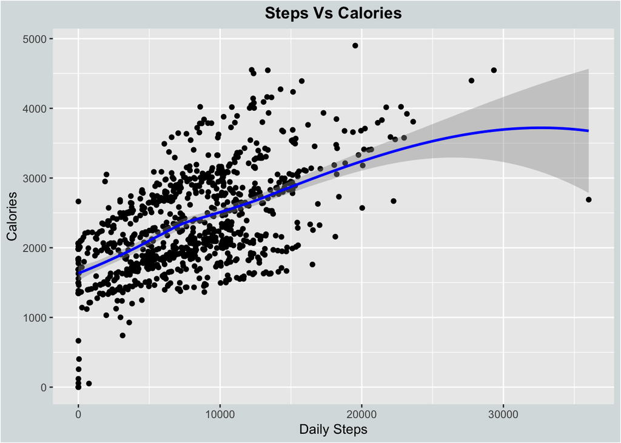

```r
ggplot(Daily_Activity, aes(x = TotalSteps, y = Calories)) +
  geom_jitter() +
  geom_smooth(method = "loess", color = "blue") +
  labs(title = "Steps Vs Calories", x = "Daily Steps", y = "Calories") +
  theme(plot.background = element_rect(fill = "#D9DFE0")) +
  theme(plot.title = element_text(hjust = 0.5)) +
  theme(plot.title = element_text(face = "bold"))
```

##### To view the relationship betwen Total active minutes and calories burnt

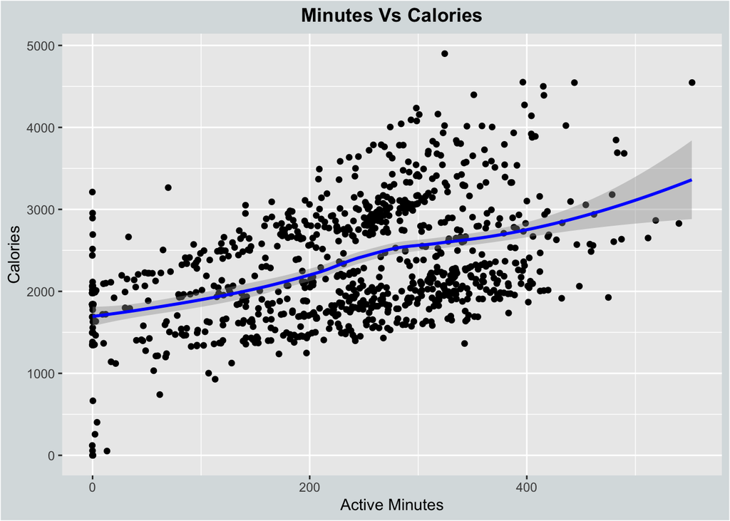

```r
DA_1 <- Daily_Activity %>%
  mutate(TotalActiveMinutes = FairlyActiveMinutes + LightlyActiveMinutes + VeryActiveMinutes)
ggplot(data = DA_1, mapping = aes(x = TotalActiveMinutes, y = Calories)) +
  geom_jitter() +
  geom_smooth(method = "loess", color = "blue") +
  labs(title = "Minutes Vs Calories", x = "Active Minutes", y = "Calories") +
  theme(plot.background = element_rect(fill = "#D9DFE0")) +
  theme(plot.title = element_text(hjust = 0.5)) +
  theme(plot.title = element_text(face = "bold"))
```

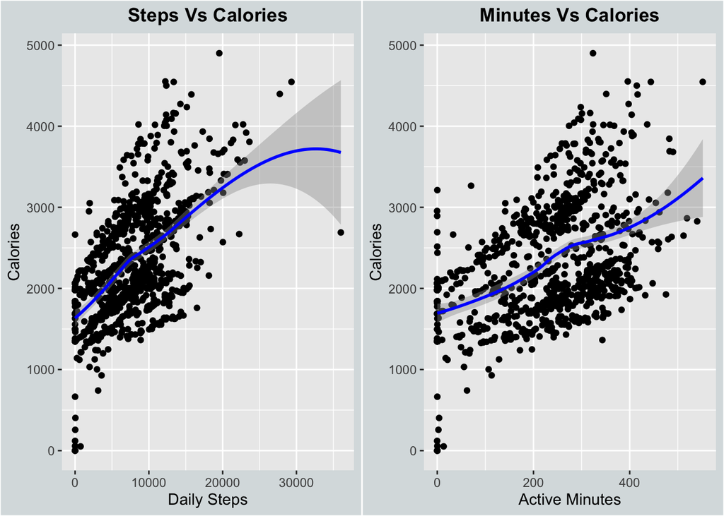

```r
ggarrange(
  ggplot(Daily_Activity, aes(x = TotalSteps, y = Calories)) +
    geom_jitter() +
    geom_smooth(method = "loess", color = "blue") +
    labs(title = "Steps Vs Calories", x = "Daily Steps", y = "Calories") +
    theme(plot.background = element_rect(fill = "#D9DFE0")) +
    theme(plot.title = element_text(hjust = 0.5)) +
    theme(plot.title = element_text(face = "bold")),
  ggplot(data = DA_1, mapping = aes(x = TotalActiveMinutes, y = Calories)) +
    geom_jitter() +
    geom_smooth(method = "loess", color = "blue") +
    labs(title = "Minutes Vs Calories", x = "Active Minutes", y = "Calories") +
    theme(plot.background = element_rect(fill = "#D9DFE0")) +
    theme(plot.title = element_text(hjust = 0.5)) +
    theme(plot.title = element_text(face = "bold")))
```

##### To view the relationship between Time in Bed Vs Minutes Asleep

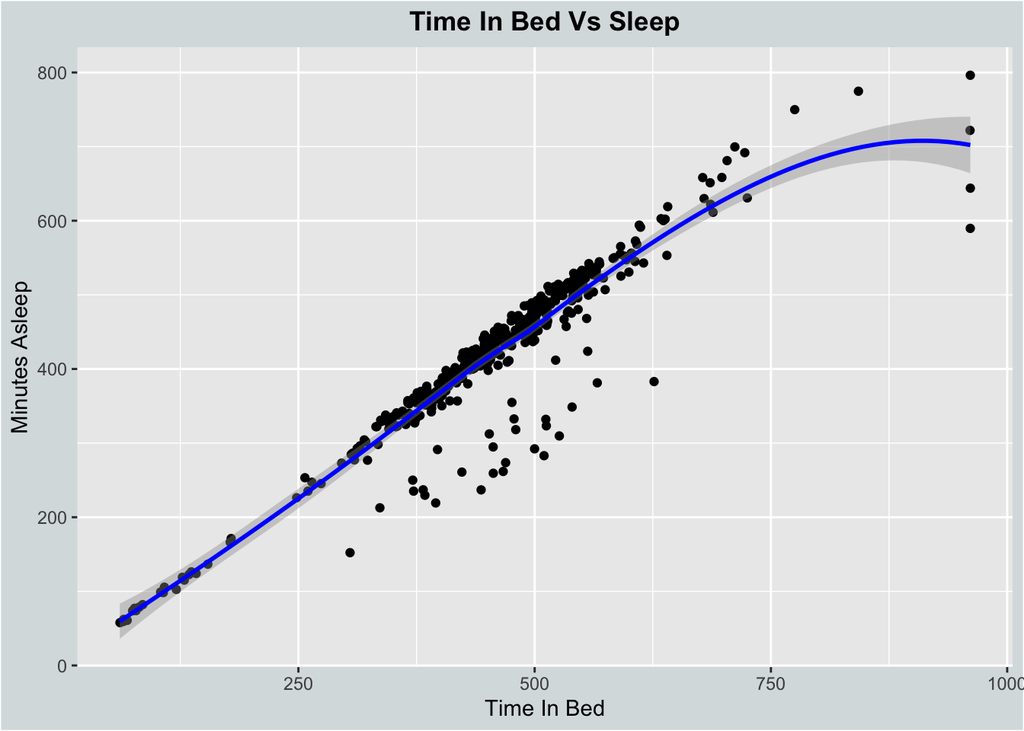

```r
ggplot(Daily_Sleep, aes(x = TotalTimeInBed, y = TotalMinutesAsleep)) +
  geom_jitter() +
  geom_smooth(method = "loess", color = "blue") +
  labs(title = "Time In Bed Vs Sleep", x = "Time In Bed", y = "Minutes Asleep") +
  theme(plot.background = element_rect(fill = "#D9DFE0")) +
  theme(plot.title = element_text(hjust = 0.5)) +
  theme(plot.title = element_text(face = "bold"))
```

##### To view the number of steps taken by users in each hour of the day

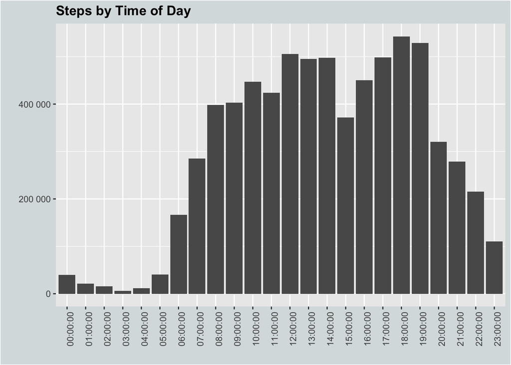

```r
ggplot(data = Hourly_Steps_2) +
  geom_col(mapping = aes(x=Time, y = Number_of_Steps)) +
  labs(title = "Steps by Time of Day", x="", y="") +
  scale_fill_gradient(low = "blue", high = "darkgreen") +
  theme(axis.text.x = element_text(angle = 90)) +
  theme(plot.background = element_rect(fill = "#D9DFE0")) +
  theme(plot.title = element_text(face = "bold")) +
  scale_y_continuous(labels = number)
```

##### To view average daily step taken by users in each hour of the day

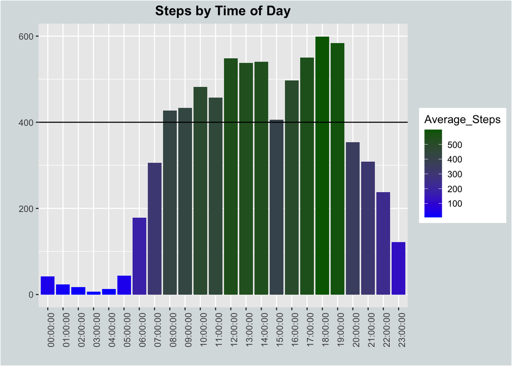

```r
ggplot(data = Hourly_Steps_2) +
  geom_col(mapping = aes(x=Time, y = Average_Steps, fill = Average_Steps)) +
  labs(title = "Steps by Time of Day", x="", y="") +
  scale_fill_gradient(low = "blue", high = "darkgreen") +
  theme(axis.text.x = element_text(angle = 90)) +
  geom_hline(yintercept = 400 ) +
  theme(plot.background = element_rect(fill = "#D9DFE0")) +
  theme(plot.title = element_text(hjust = 0.5)) +
  theme(plot.title = element_text(face = "bold"))
```

##### To view the relationship between daily steps and sedentary minutes

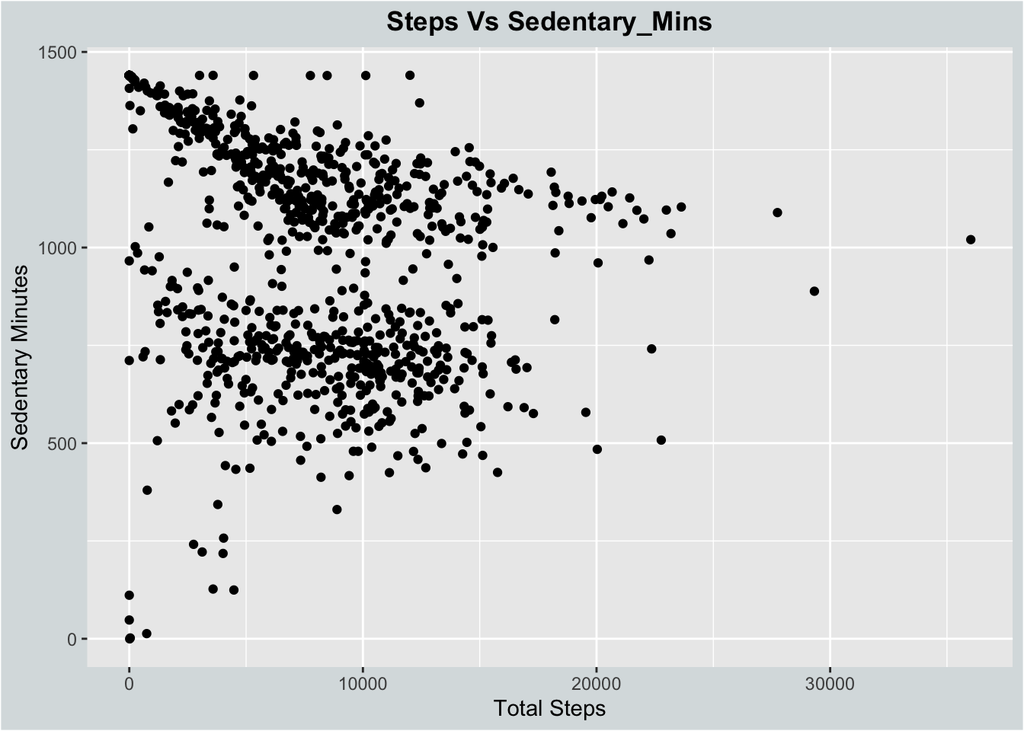

```r
ggplot(Daily_Activity, aes(x = TotalSteps, y = SedentaryMinutes)) +
  geom_jitter() +
  labs(title = "Steps Vs Sedentary_Mins", x = "Total Steps", y = "Sedentary Minutes") +
  theme(plot.background = element_rect(fill = "#D9DFE0")) +
  theme(plot.title = element_text(hjust = 0.5)) +
  theme(plot.title = element_text(face = "bold"))
```

##### To view the relationship between daily steps and daily sleep

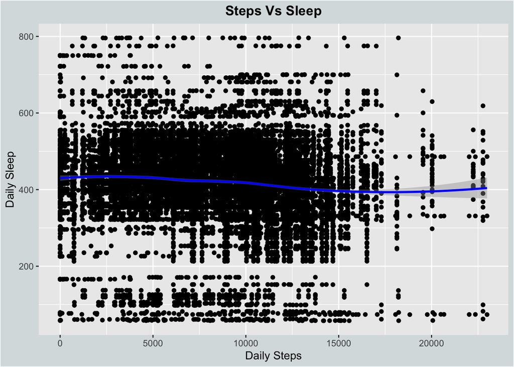

```r
ggplot(Combined_Data, aes(x = TotalSteps, y = TotalMinutesAsleep)) +
  geom_jitter() +
  geom_smooth(method = "loess", color = "blue") +
  labs(title = "Steps Vs Sleep", x = "Daily Steps", y = "Daily Sleep") +
  theme(plot.background = element_rect(fill = "#D9DFE0")) +
  theme(plot.title = element_text(hjust = 0.5)) +
  theme(plot.title = element_text(face = "bold"))
```

##### To view average step taken (during the weekday) daily by users

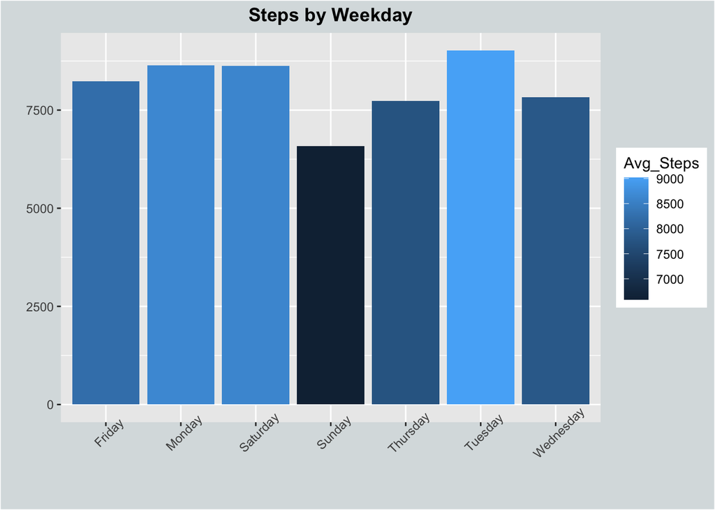

```r
Combined_B <- Combined_Data %>%
  mutate(Day = weekdays(Date.x)) %>%
  group_by(Day) %>%
  summarize(Number_of_Steps = sum(TotalSteps),
            Avg_Steps = mean(TotalSteps),
            Avg_Sleep = mean(TotalMinutesAsleep))
ggplot(data = Combined_B) +
  geom_col(mapping = aes(x=Day, y = Avg_Steps, fill = Avg_Steps)) +
  labs(title = "Steps by Weekday", x="", y ="") +
  theme(axis.text.x = element_text(angle = 45)) +
  theme(plot.background = element_rect(fill = "#D9DFE0")) +
  theme(plot.title = element_text(hjust = 0.5)) +
  theme(plot.title = element_text(face = "bold"))
```

##### To view the average minutes of sleep (during the weekday) daily by users

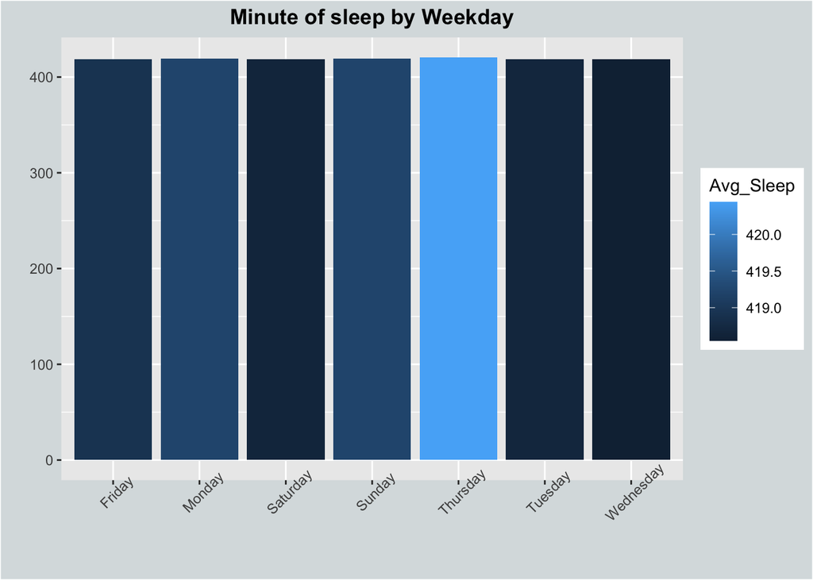

```r
Combined_C <- Combined_Data %>%
  mutate(Day = weekdays(Date.x)) %>%
  group_by(Day) %>%
  summarize(Number_of_Steps = sum(TotalSteps),
            Avg_Steps = mean(TotalSteps),
            Avg_Sleep = mean(TotalMinutesAsleep))
ggplot(data = Combined_C) +
  geom_col(mapping = aes(x=Day, y = Avg_Sleep, fill = Avg_Sleep)) +
  labs(title = "Minute of sleep by Weekday", x="", y ="") +
  theme(axis.text.x = element_text(angle = 45)) +
  theme(plot.background = element_rect(fill = "#D9DFE0")) +
  theme(plot.title = element_text(hjust = 0.5)) +
  theme(plot.title = element_text(face = "bold"))
```